# Microbial Composition Analysis Across Cheese Types

Chloe J McGovern

2025-04-30

# Setup

## Load Packages

```r
# Load in the packages
pacman::p_load(tidyverse, devtools, DT, phyloseq, patchwork, FSA,
               install = FALSE)

#install.packages("FSA")

# load colors
source("code/colors.R")
```

# Goals

In this file, we will perform compositional analysis of our scaled/noramlized/rarefied microbial dataset!

1. Load in scaled/normalized phyloseq object.
2. Calculate the relative abundances of taxonomic groups at various levels: A. Phylum B. Genus C. ASV
3. Plot them, and narrow in on specific taxnomic group of interest
1. We will need the `scaled_physeq.RData`, which includes a rooted tree that we created in `analysis/06_Ordination/scaled_physeq.RData`.

## Outputs

# Compositional Data

Microbial abundance data—like 16S rRNA gene or metagenomics data—are typically **compositional:** they represent relative abundances constrained to a constant total (*e.g.,* percent or proportions). This introduces spurious correlations and other issues if analyzed with traditional statistics. This is a very important limitation to microbial data!

Interpretation 1: Microbial abundance was assessed using relative data, which reflects the proportion of each taxon within a sample rather than absolute counts. Changes in one taxon’s relative abundance may artificially suggest shifts in others due to the fixed total constraint. This limits interpretation of true microbial load and community dynamics.

## 1. Load in Scaled Phyloseq object

```r
load("data/06_Ordination/scaled_physeq.RData")

# Look at the data
scaled_physeq
```

```
## phyloseq-class experiment-level object
## otu_table()   OTU Table:         [ 93 taxa and 20 samples ]
## sample_data() Sample Data:       [ 20 samples by 45 sample variables ]
## tax_table()   Taxonomy Table:    [ 93 taxa by 9 taxonomic ranks ]
## phy_tree()    Phylogenetic Tree: [ 93 tips and 92 internal nodes ]
```

```r
# Intuition check - scaled at 1,942
min(sample_sums(scaled_physeq))
```

```
## [1] 32002
```

```r
range(sample_sums(scaled_physeq))
```

```
## [1] 32002 32005
```

# Taxonomic Analysis!

In this analysis, we will drill down from phylum to ASV level analyses, which will enable increasingly detailed insights into microbial diversity and potential ecological roles. However, it is also important for us to remember that deeper levels also come with increased noise and data sparsity, especially for rare groups.

## A. Phylum

```r
# Create a phylum level dataframe
phylum_df <-
  scaled_physeq %>%
  # Agglomerate all ASV counts within a phylum
  tax_glom(taxrank = "Phylum") %>%
  # Calculate the relative abundance!
  transform_sample_counts(function(x) {x/sum(x)}) %>%
  # Create a dataframe from phyloseq object
  psmelt()
  # Filter out Phyla < 1 %
  #dplyr::filter(Abundance > 0.01)

## What are the phylum abundances?
phylum_df %>%
  group_by(Phylum) %>%
  summarize(mean_PercAbund = round(mean(Abundance), digits = 4)) %>%
  arrange(-mean_PercAbund) %>%
  datatable()
```

|  | Phylum | mean_PercAbund |
| --- | --- | --- |
| 1 | Bacillota | 0.9702 |
| 2 | Pseudomonadota | 0.0297 |
| 3 | Actinomycetota | 0.0001 |
| 4 | Bacteroidota | 0 |
| 5 | Chloroflexota | 0 |

```r
# Make a list of phyla the top phyla
top10_phyla <-
  phylum_df %>%
  group_by(Phylum) %>%
  summarize(mean_PercAbund = mean(Abundance)) %>%
  arrange(-mean_PercAbund) %>%
  head(n = 10) %>%
  pull(Phylum)

top10_phyla
```

```
## [1] "Bacillota"      "Pseudomonadota" "Actinomycetota" "Bacteroidota"
## [5] "Chloroflexota"
```

Bacteroidota, Chloroflexota, and Actinomycetota are in such small amounts (0, 0, and 0.0001 is what R rounds them too) so I think for continual analysis I will only focus on the Bacillota and Pseudomonadota phyla.

## Stacked Bar Plots

```r
# Stacked Bar Plot With All phyla
# Plot Phylum Abundances - make sure to load phylum_colors

## need to add cheese_type column first

colnames(phylum_df)
```

```
##  [1] "OTU"                            "Sample"
##  [3] "Abundance"                      "Assay.Type"
##  [5] "AvgSpotLen"                     "Bases"
##  [7] "BioProject"                     "BioSample"
##  [9] "BioSampleModel"                 "Bytes"
## [11] "Center.Name"                    "cheese_id"
## [13] "Collection_Date"                "Consent"
## [15] "Cultivar"                       "DATASTORE.filetype"
## [17] "DATASTORE.provider"             "DATASTORE.region"
## [19] "Ecotype"                        "env_broad_scale"
## [21] "env_local_scale"                "env_medium"
## [23] "Experiment"                     "geo_loc_name_country"
## [25] "geo_loc_name_country_continent" "geo_loc_name"
## [27] "Instrument"                     "isol_growth_condt"
## [29] "isolate"                        "lat_lon"
## [31] "Library.Name"                   "LibraryLayout"
## [33] "LibrarySelection"               "LibrarySource"
## [35] "Organism"                       "Platform"
## [37] "ReleaseDate"                    "create_date"
## [39] "version"                        "Sample.Name"
## [41] "SRA.Study"                      "strain"
## [43] "names"                          "denoisedF"
## [45] "denoisedR"                      "merged"
## [47] "nochim"                         "num_ASVs"
## [49] "Kingdom"                        "Phylum"
```

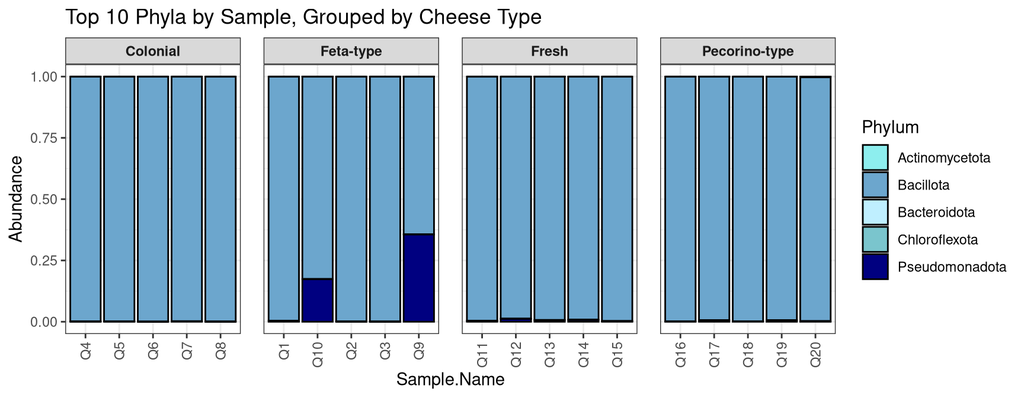

```r
phylum_df <-
  phylum_df %>%
    mutate(cheese_type = case_when(
    Sample.Name %in% c("Q4", "Q5", "Q6", "Q7", "Q8") ~ "Colonial",
    Sample.Name %in% c("Q1", "Q2", "Q3", "Q9", "Q10") ~ "Feta-type",
    Sample.Name %in% c("Q15", "Q14", "Q13", "Q12", "Q11") ~ "Fresh",
    Sample.Name %in% c("Q16", "Q17", "Q18", "Q19", "Q20") ~ "Pecorino-type"
  ))

#View(phylum_df)


phylum_df %>%
  filter(Phylum %in% top10_phyla) %>%
  ggplot(aes(x = Sample.Name, y = Abundance, fill = Phylum)) +
  facet_grid(. ~ cheese_type, scales = "free_x", space = "free_x") +  # Group by cheese type
  geom_bar(stat = "identity", color = "black") +
  scale_fill_manual(values = phylum_colors) +
  labs(title = "Top 10 Phyla by Sample, Grouped by Cheese Type") +
  theme_bw() +
  theme(
    axis.text.x = element_text(angle = 90, hjust = 1, vjust = 0.5),
    strip.text = element_text(face = "bold"),
    panel.spacing.x = unit(1, "lines")
  )
```

## Faceted Bar plot

To help compare the phylum abundance between sample types, we can facet by phylum to better see how the changes occur across the stations, which is masked in the stacked bar plot. It’s a little better than the stacked bar plot, however, we can do even better!

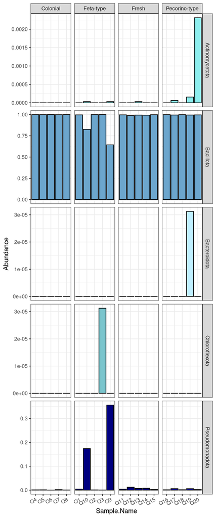

```r
phylum_df %>%
  dplyr::filter(Phylum %in% top10_phyla) %>%
  ggplot(aes(x = Sample.Name, y = Abundance, fill = Phylum)) +
  facet_grid(Phylum~cheese_type, scale = "free") +
  # add the stacked bar
  geom_bar(stat = "identity", color = "black") +
  # change the colors to be our selected colors
  scale_fill_manual(values = phylum_colors) +
  theme_bw() +
  theme(legend.position = "none",
        axis.text.x = element_text(angle = 30, hjust = 1, vjust = 1))
```

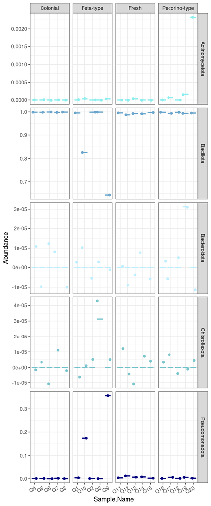

```r
### Or combined together:
phylum_df %>%
  dplyr::filter(Phylum %in% top10_phyla) %>%
  ggplot(aes(x = Sample.Name, y = Abundance, fill = Phylum, color = Phylum)) +
  facet_grid(Phylum~cheese_type, scale = "free") +
  # add the stacked bar
  geom_jitter() +
  geom_boxplot(outlier.shape = NA, alpha = 0.5) +
  # change the colors to be our selected colors
  scale_fill_manual(values = phylum_colors) +
  scale_color_manual(values = phylum_colors) +
  theme_bw() +
  theme(legend.position = "none",
        axis.text.x = element_text(angle = 30, hjust = 1, vjust = 1))
```

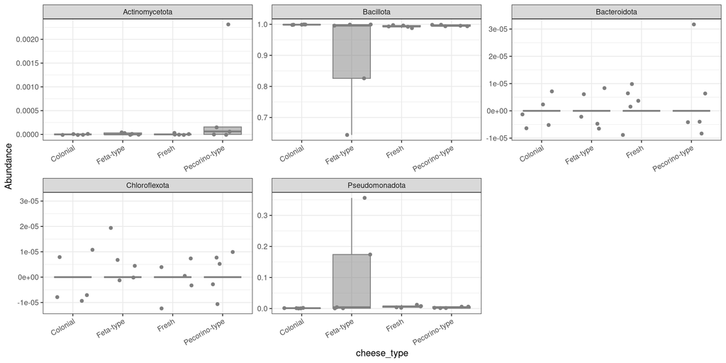

```r
### Or combined together:
phylum_df %>%
  dplyr::filter(Phylum %in% top10_phyla) %>%
  ggplot(aes(x = cheese_type, y = Abundance, fill = Phylum, color = Phylum)) +
  facet_wrap(Phylum~., scales = "free", nrow = 2) +
  # add the stacked bar
  geom_jitter() +
  geom_boxplot(outlier.shape = NA, alpha = 0.5) +
  # change the colors to be our selected colors
  scale_fill_manual(values = cheese_colors) +
  scale_color_manual(values = cheese_colors) +
  theme_bw() +
  theme(legend.position = "none",
        axis.text.x = element_text(angle = 30, hjust = 1, vjust = 1))
```

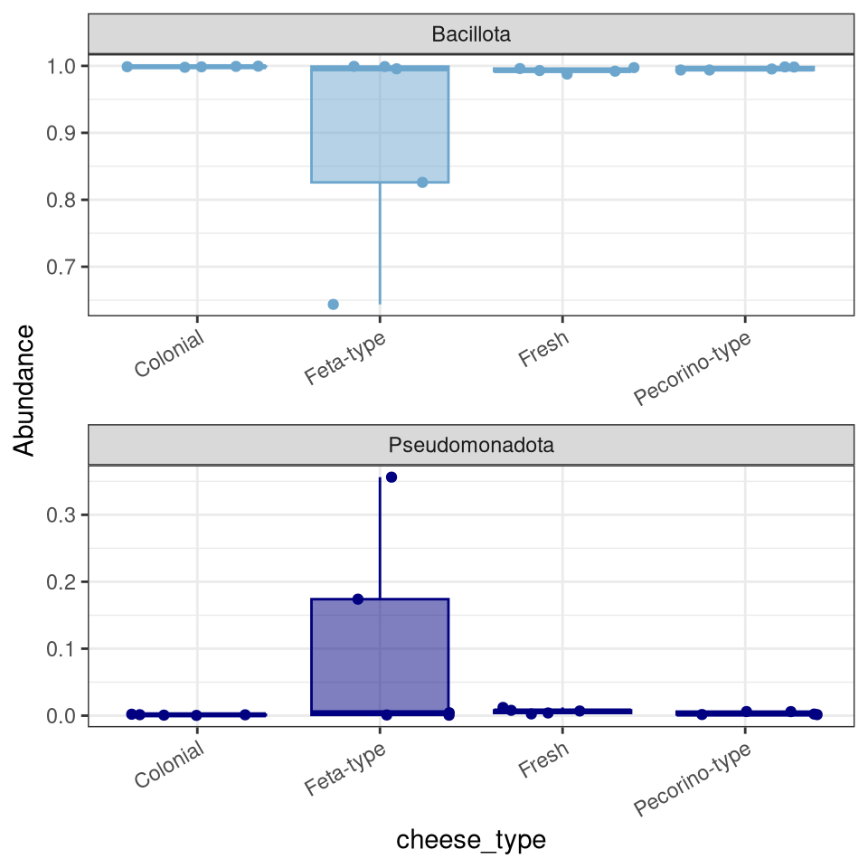

```r
# just important two phyla

phylum_df %>%
  dplyr::filter(Phylum %in% c("Bacillota", "Pseudomonadota")) %>%
  ggplot(aes(x = cheese_type, y = Abundance, fill = Phylum, color = Phylum)) +
  facet_wrap(Phylum ~ ., scales = "free", nrow = 2) +
  geom_jitter() +
  geom_boxplot(outlier.shape = NA, alpha = 0.5) +
  scale_fill_manual(values = phylum_colors) +
  scale_color_manual(values = phylum_colors) +
  theme_bw() +
  theme(
    legend.position = "none",
    axis.text.x = element_text(angle = 30, hjust = 1, vjust = 1)
  )
```

Interpretation 3: Microbial composition across cheese types is consistently dominated by Bacillota, indicating its foundational role in cheese microbial communities. However, the increased relative abundance of Pseudomonadota in Feta-type cheeses suggests that cheese style may influence the presence or enrichment of certain microbial groups. This pattern supports the hypothesis that cheese processing conditions — such as moisture, salting, or aging — shape microbial community structure, even at the phylum level.

### A1. Bacillota

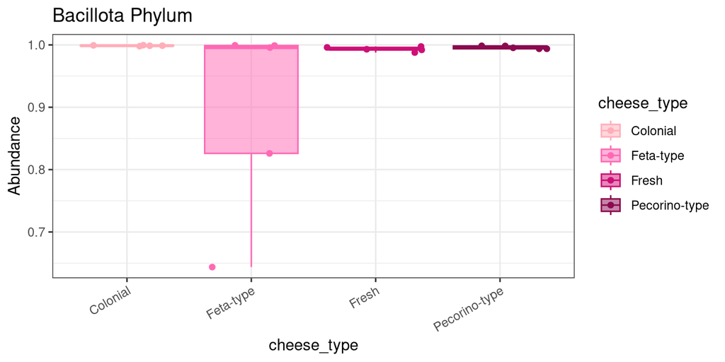

```r
# Narrow in on a specific group
# Bacillota - y: abundance, x: cheese_type, dot plot + boxplot
bacillota_phylum_cheese <-
  phylum_df %>%
  dplyr::filter(Phylum == "Bacillota") %>%
  # build the plot
  ggplot(aes(x = cheese_type, y = Abundance,
             fill = cheese_type, color = cheese_type)) +
  geom_boxplot(alpha = 0.5, outlier.shape = NA) + # outliers not plotted here in boxplot
  geom_jitter() +
  theme_bw() +
  labs(title = "Bacillota Phylum") +
  scale_color_manual(values = cheese_colors) +
  scale_fill_manual(values = cheese_colors) +
    theme(axis.text.x = element_text(angle = 30, hjust = 1, vjust = 1),
          legend.position = "right")

bacillota_phylum_cheese
```

```r
kruskal.test(Abundance ~ cheese_type, data = filter(phylum_df, Phylum == "Bacillota")) # no significant difference
```

```
##
##  Kruskal-Wallis rank sum test
##
## data:  Abundance by cheese_type
## Kruskal-Wallis chi-squared = 7.0457, df = 3, p-value = 0.07045
```

```r
dunnTest(Abundance ~ cheese_type,
         data = filter(phylum_df, Phylum == "Bacillota"),
         method = "bh") #no secret pairwise comparisons
```

```
## Dunn (1964) Kruskal-Wallis multiple comparison
```

```
##   p-values adjusted with the Benjamini-Hochberg method.
```

```
##                  Comparison          Z    P.unadj      P.adj
## 1      Colonial - Feta-type  1.7639242 0.07774474 0.15548948
## 2          Colonial - Fresh  2.5657079 0.01029655 0.06177929
## 3         Feta-type - Fresh  0.8017837 0.42267807 0.50721369
## 4  Colonial - Pecorino-type  1.7639242 0.07774474 0.23323423
## 5 Feta-type - Pecorino-type  0.0000000 1.00000000 1.00000000
## 6     Fresh - Pecorino-type -0.8017837 0.42267807 0.63401711
```

### A2. Pseudomonadota

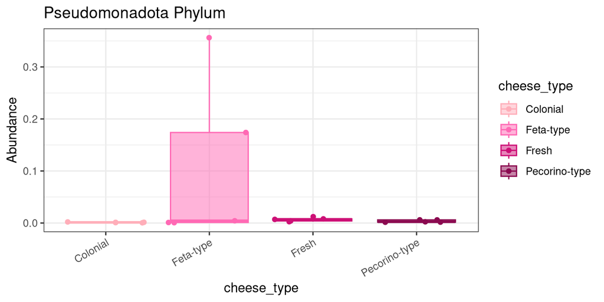

```r
# Narrow in on a specific group
# Bacillota - y: abundance, x: cheese_type, dot plot + boxplot
pseudo_phylum_cheese <-
  phylum_df %>%
  dplyr::filter(Phylum == "Pseudomonadota") %>%
  # build the plot
  ggplot(aes(x = cheese_type, y = Abundance,
             fill = cheese_type, color = cheese_type)) +
  geom_boxplot(alpha = 0.5, outlier.shape = NA) + # outliers not plotted here in boxplot
  geom_jitter() +
  theme_bw() +
  labs(title = "Pseudomonadota Phylum") +
  scale_color_manual(values = cheese_colors) +
  scale_fill_manual(values = cheese_colors) +
    theme(axis.text.x = element_text(angle = 30, hjust = 1, vjust = 1),
          legend.position = "right")

pseudo_phylum_cheese
```

```r
kruskal.test(Abundance ~ cheese_type, data = filter(phylum_df, Phylum == "Pseudomonadota")) # p = 0.05!! maybe there is a pairwise!
```

```
##
##  Kruskal-Wallis rank sum test
##
## data:  Abundance by cheese_type
## Kruskal-Wallis chi-squared = 7.4686, df = 3, p-value = 0.05837
```

```r
dunnTest(Abundance ~ cheese_type,
         data = filter(phylum_df, Phylum == "Pseudomonadota"),
         method = "bh") # Colonial - Fresh p = 0.04!
```

```
## Dunn (1964) Kruskal-Wallis multiple comparison
```

```
##   p-values adjusted with the Benjamini-Hochberg method.
```

```
##                  Comparison         Z     P.unadj      P.adj
## 1      Colonial - Feta-type -1.817376 0.069159492 0.20747848
## 2          Colonial - Fresh -2.672612 0.007526315 0.04515789
## 3         Feta-type - Fresh -0.855236 0.392420524 0.47090463
## 4  Colonial - Pecorino-type -1.603567 0.108809430 0.21761886
## 5 Feta-type - Pecorino-type  0.213809 0.830696011 0.83069601
## 6     Fresh - Pecorino-type  1.069045 0.285049407 0.42757411
```

Interpretation 4: Unfortunately, due to the lesser complexity of cheese microbial communities, I am stuck with these two phyla to dig into–I hope at the genus level there are some interesting community shifts! I am shocked that the spread of the feta-type analysis didn’t result in any significant differences.

## B. Genus

Let’s first calculate the genus data frame.

```r
# Calculate the Family relative abundance
# Note: The read depth MUST be normalized in some way: scale_reads
genus_df <-
  scaled_physeq %>%
  # agglomerate at the phylum level
  tax_glom(taxrank = "Genus") %>%
  # Transform counts to relative abundance
  transform_sample_counts(function (x) {x/sum(x)}) %>%
  # Melt to a long format
  psmelt()

#genus_df #too big to print

# add cheese_type
Genus_DF <-
  genus_df %>%
  mutate(cheese_type = case_when(
    Sample.Name %in% c("Q4", "Q5", "Q6", "Q7", "Q8") ~ "Colonial",
    Sample.Name %in% c("Q1", "Q2", "Q3", "Q9", "Q10") ~ "Feta-type",
    Sample.Name %in% c("Q15", "Q14", "Q13", "Q12", "Q11") ~ "Fresh",
    Sample.Name %in% c("Q16", "Q17", "Q18", "Q19", "Q20") ~ "Pecorino-type"
  ))

#View(Genus_DF)

top_genera <- Genus_DF %>%
  group_by(Genus) %>%
  summarise(TotalAbundance = sum(Abundance, na.rm = TRUE)) %>%
  arrange(desc(TotalAbundance))

top_genus_names <- top_genera$Genus

top_genus_names
```

```
##  [1] "Streptococcus"          "Lactobacillus"          "Lactococcus"
##  [4] "Yersinia"               "Staphylococcus"         "Klebsiella"
##  [7] "Phyllobacterium"        "Raoultella"             "Lacticaseibacillus"
## [10] "Pseudomonas"            "Enterococcus"           "Marinilactibacillus"
## [13] "Mammaliicoccus"         "Leuconostoc"            "Pseudoalteromonas"
## [16] "Kurthia"                "Serratia"               "Stenotrophomonas"
## [19] "Brevibacterium"         "Psychrobacter"          "Chromohalobacter"
## [22] "Carnobacterium"         "Acinetobacter"          "Hafnia-Obesumbacterium"
## [25] "Sphingomonas"           "Macrococcus"            "Halomonas"
## [28] "Cobetia"                "Escherichia-Shigella"   "Lentilactobacillus"
## [31] "Lactiplantibacillus"    "Pediococcus"            "Bacillus"
## [34] "Acetobacter"            "Levilactobacillus"      "Vibrio"
## [37] "Sphingobium"            "Agrilactobacillus"      "Clostridium"
## [40] "Limosilactobacillus"    "Novosphingobium"        "Rothia"
## [43] "Dietzia"                "Yokenella"              "HSB OF53-F07"
```

### B1. Bacillota Genera

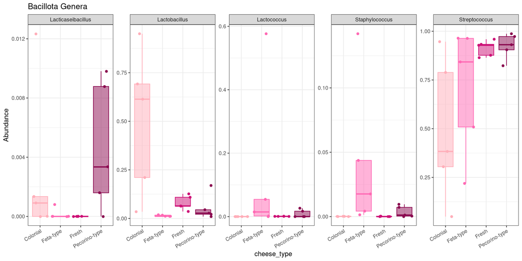

```r
# Bacillota
# Plot genus
bacillota_genus_cheese <-
  Genus_DF %>%
  dplyr::filter(Phylum == "Bacillota") %>%
  # At first, plot all of the genera and then subset the ones that have intersting trends
  dplyr::filter(Genus %in% c("Streptococcus", "Lactobacillus", "Lactococcus", "Lacticaseibacillus", "Staphylococcus")) %>%
  # build the plot
  ggplot(aes(x = cheese_type, y = Abundance,
             fill = cheese_type, color = cheese_type)) +
  facet_wrap(.~Genus, scales = "free_y", nrow = 1) +
  geom_boxplot(alpha = 0.5, outlier.shape = NA) + # outliers not plotted here in boxplot
  geom_jitter() +
  theme_bw() +
  labs(title = "Bacillota Genera") +
  scale_color_manual(values = cheese_colors) +
  scale_fill_manual(values = cheese_colors) +
  theme(axis.text.x = element_text(angle = 30, hjust = 1, vjust = 1),
        legend.position = "none")


bacillota_genus_cheese
```

### B2. Pseudomonadota Genera

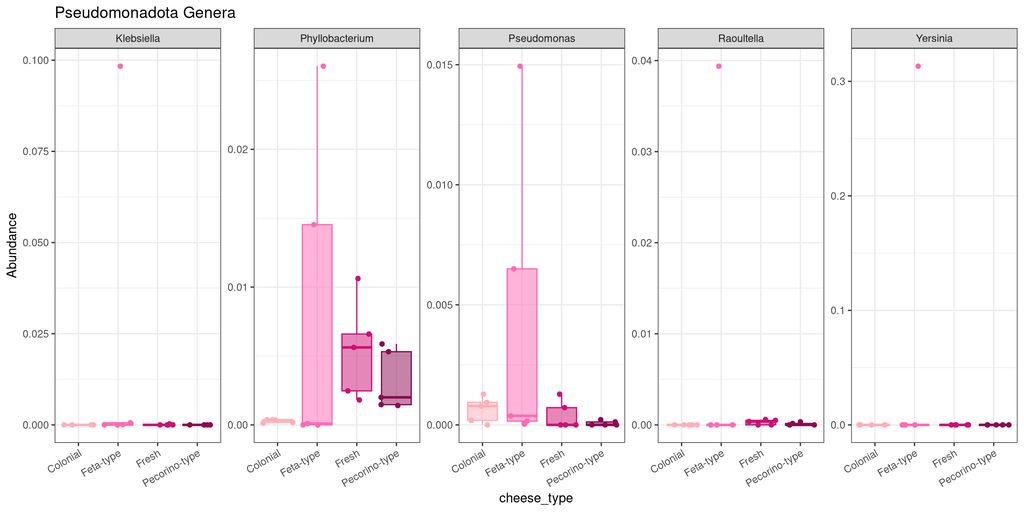

```r
# Plot genus
pseudo_genus_cheese <-
  Genus_DF %>%
  dplyr::filter(Phylum == "Pseudomonadota") %>%
  # At first, plot all of the genera and then subset the ones that have intersting trends
  dplyr::filter(Genus %in% c("Klebsiella", "Phyllobacterium", "Raoultella", "Yersinia", "Pseudomonas")) %>%
  # build the plot
  ggplot(aes(x = cheese_type, y = Abundance,
             fill = cheese_type, color = cheese_type)) +
  facet_wrap(.~Genus, scales = "free_y", nrow = 1) +
  geom_boxplot(alpha = 0.5, outlier.shape = NA) + # outliers not plotted here in boxplot
  geom_jitter() +
  theme_bw() +
  labs(title = "Pseudomonadota Genera") +
  scale_color_manual(values = cheese_colors) +
  scale_fill_manual(values = cheese_colors) +
  theme(axis.text.x = element_text(angle = 30, hjust = 1, vjust = 1),
        legend.position = "none")


pseudo_genus_cheese
```

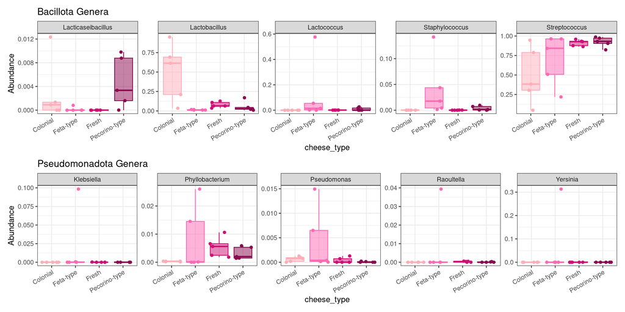

```r
bacillota_genus_cheese / pseudo_genus_cheese
```

Interpretation 5: To explore mid-level taxonomic trends, I generated genus-level plots for dominant phyla identified in the initial analysis. This revealed meaningful differences masked at the phylum level. For example, while Bacillota appeared consistently dominant across cheese types, this pattern was largely driven by a single genus, Streptococcus, with other genera such as Lactobacillus and Lacticaseibacillus showing more variable, cheese-type-specific distributions. Similarly, while Pseudomonadota appeared low in overall abundance, genus-level plots revealed sporadic spikes in Yersinia, Klebsiella, and Pseudomonas in select samples. Given that a small number of dominant genera accounted for the majority of abundance, plotting intermediate ranks like family or order did not add interpretive value beyond the genus level.

## C. ASV level

```r
# Calculate the Family relative abundance
# Note: The read depth MUST be normalized in some way: scale_reads
ASV_df <-
  scaled_physeq %>%
  # Prune out ASVs that have fewer than 100 counts!
  ## LOOK AT HOW MANY ARE REMOVED! We scaled to 1,962 reads!
  prune_taxa(taxa_sums(.) >= 196, .) %>%
  # agglomerate at the phylum level
  tax_glom(taxrank = "ASV") %>%
  # Transform counts to relative abundance
  transform_sample_counts(function (x) {x/sum(x)}) %>%
  # Melt to a long format
  psmelt() %>%
  # add cheese_type
  mutate(cheese_type = case_when(
    Sample.Name %in% c("Q4", "Q5", "Q6", "Q7", "Q8") ~ "Colonial",
    Sample.Name %in% c("Q1", "Q2", "Q3", "Q9", "Q10") ~ "Feta-type",
    Sample.Name %in% c("Q15", "Q14", "Q13", "Q12", "Q11") ~ "Fresh",
    Sample.Name %in% c("Q16", "Q17", "Q18", "Q19", "Q20") ~ "Pecorino-type"
  ))
```

### C1. Bacillota ASVs

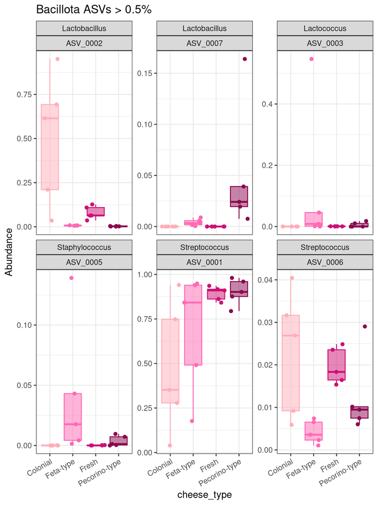

```r
# Calculate top couple of ASVs
# Make a list of phyla the top phyla
top_bacillota_ASVs <-
  ASV_df %>%
  dplyr::filter(Phylum == "Bacillota") %>%
  group_by(ASV) %>%
  summarize(mean_Abundance = mean(Abundance)) %>%
  dplyr::filter(mean_Abundance > 0.005) %>%
  pull(ASV)

# Plot ASVs
bacillota_asv_cheese <-
  ASV_df %>%
  dplyr::filter(ASV %in% top_bacillota_ASVs) %>%
  # build the plot
  ggplot(aes(x = cheese_type, y = Abundance,
             fill = cheese_type, color = cheese_type)) +
  facet_wrap(Genus~ASV, scales = "free_y", nrow = 2) +
  geom_boxplot(alpha = 0.5, outlier.shape = NA) + # outliers not plotted here in boxplot
  geom_jitter() +
  theme_bw() +
  labs(title = "Bacillota ASVs > 0.5%") +
  scale_color_manual(values = cheese_colors) +
  scale_fill_manual(values = cheese_colors) +
  theme(axis.text.x = element_text(angle = 30, hjust = 1, vjust = 1),
        legend.position = "none")

bacillota_asv_cheese
```

### C2. Pseudomonadota ASVs

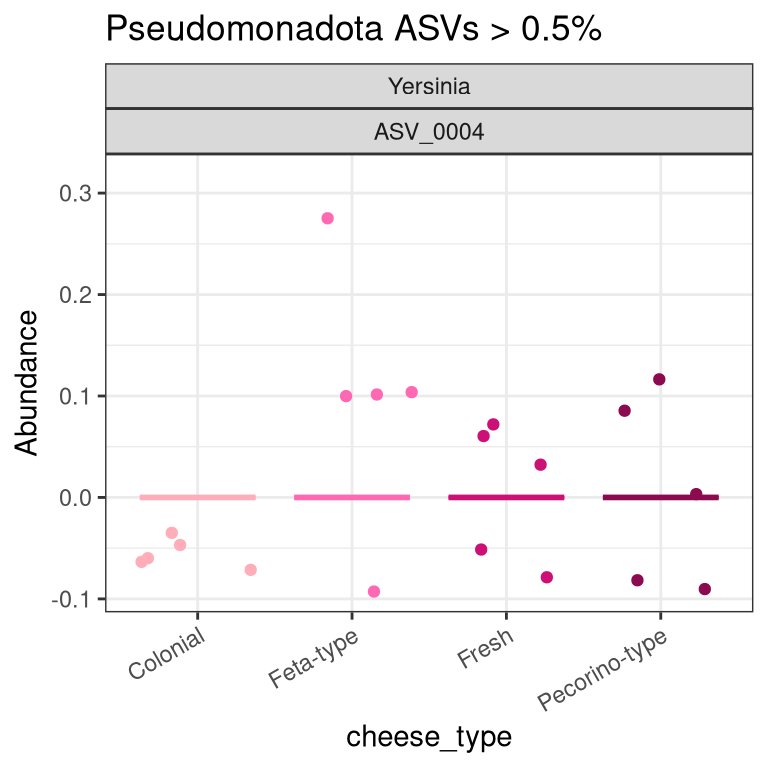

```r
# Calculate top couple of ASVs
# Make a list of phyla the top phyla
top_pseudo_ASVs <-
  ASV_df %>%
  dplyr::filter(Phylum == "Pseudomonadota") %>%
  group_by(ASV) %>%
  summarize(mean_Abundance = mean(Abundance)) %>%
  dplyr::filter(mean_Abundance > 0.005) %>%
  pull(ASV)

# Plot ASVs: Station
pseudo_asv_cheese <-
  ASV_df %>%
  # Subset for more abundant ASVs
  dplyr::filter(ASV %in% top_pseudo_ASVs) %>%
  # build the plot
  ggplot(aes(x = cheese_type, y = Abundance,
             fill = cheese_type, color = cheese_type)) +
  facet_wrap(Genus~ASV, scales = "free_y", nrow = 2) +
  geom_boxplot(alpha = 0.5, outlier.shape = NA) + # outliers not plotted here in boxplot
  geom_jitter() +
  theme_bw() +
  labs(title = "Pseudomonadota ASVs > 0.5%") +
  scale_color_manual(values = cheese_colors) +
  scale_fill_manual(values = cheese_colors) +
  theme(axis.text.x = element_text(angle = 30, hjust = 1, vjust = 1),
        legend.position = "none")

pseudo_asv_cheese
```

Interpretation 7: Several ASVs within the Bacillota phylum—particularly Streptococcus ASV_0001, Lactobacillus ASV_0002, and Staphylococcus ASV_0005—show clear and consistent differences across cheese types. For example, Streptococcus ASV_0001 dominated in Fresh and Pecorino-type cheeses but was more variable in Colonial and Feta-type cheeses. Meanwhile, Pseudomonadota ASVs, such as Yersinia ASV_0004, were sporadically abundant in specific samples, with no consistent pattern by cheese type. This indicates that some ASVs have niche-specific associations likely shaped by cheese production practices since consistently abundant genera are most likely associated with the sheeps milk.

Interpretation 8: ASV-level analysis revealed that Streptococcus was a consistent dominant feature of Fresh and Pecorino-type cheeses, aligning with its known role in sheep milk fermentation. Other ASVs within Streptococcus and Lactobacillus showed cheese-type-specific patterns, suggesting functional strain-level diversity. The unexpected presence of Yersinia in several samples may indicate a less-studied raw milk or environmental signal. Together, these results highlight the importance of ASV-resolution for identifying both core fermenters and niche-specific microbial trends in artisanal sheep cheeses.